# research Course project

Ankit Anand Gupta

15 March 2017

Loading and preprocessing the data.

```r
activity <- read.csv("activity.csv")
```

Read data into R for analysis and take a look at the data by using the head() function. By using the str() function i will know the classes of the data. In this case there are only two, integer and factor. I will transform the variable classes to numeric(1,3) and Date(2) by specifying the colClasses option in the read.csv()function

```r
activitydata <- read.csv("activity.csv")
head(activitydata)
```

```
##   steps       date interval
## 1    NA 2012-10-01        0
## 2    NA 2012-10-01        5
## 3    NA 2012-10-01       10
## 4    NA 2012-10-01       15
## 5    NA 2012-10-01       20
## 6    NA 2012-10-01       25
```

```r
str(activitydata)
```

```
## 'data.frame':    17568 obs. of  3 variables:
##  $ steps   : int  NA NA NA NA NA NA NA NA NA NA ...
##  $ date    : Factor w/ 61 levels "2012-10-01","2012-10-02",..: 1 1 1 1 1 1 1 1 1 1 ...
##  $ interval: int  0 5 10 15 20 25 30 35 40 45 ...
```

```r
activitydata <- read.csv("activity.csv",colClasses=c("numeric","Date","numeric"))
str(activitydata)
```

```
## 'data.frame':    17568 obs. of  3 variables:
##  $ steps   : num  NA NA NA NA NA NA NA NA NA NA ...
##  $ date    : Date, format: "2012-10-01" "2012-10-01" ...
##  $ interval: num  0 5 10 15 20 25 30 35 40 45 ...
```

Transform the activity dataset by removing/excluding the NA values for easier analysis

```r
data <- activitydata[complete.cases(activitydata),]
```

### Create a histogram showing the total no. of steps taken each day.

First calculate the total no. of steps taken each day and then create a histogram.

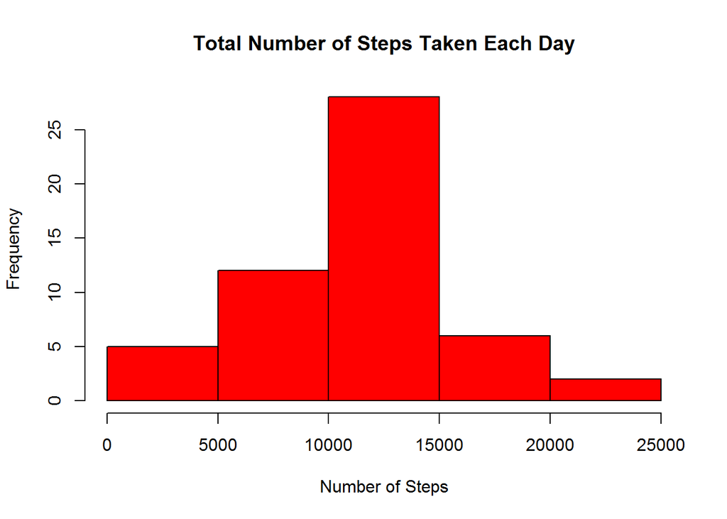

```r
totsteps <- aggregate(steps ~ date, data, sum)
hist(totsteps$steps, main = "Total Number of Steps Taken Each Day", col="red", xlab="Number of Steps")
```

### Calculate and report the mean and median no. steps taken per day.

```r
mean(totsteps$steps)
```

```
## [1] 10766.19
```

```r
median(totsteps$steps)
```

```
## [1] 10765
```

### What is the average daily activity pattern?

Create the time series plot (i.e. type = “l”) of the 5-minute interval (x-axis) and the average number of steps taken, averaged across all days (y-axis).

First calculate the mean of steps per interval using the aggregate() function.

```r
interval <- aggregate(steps ~ interval, data, mean)
```

plot a time series

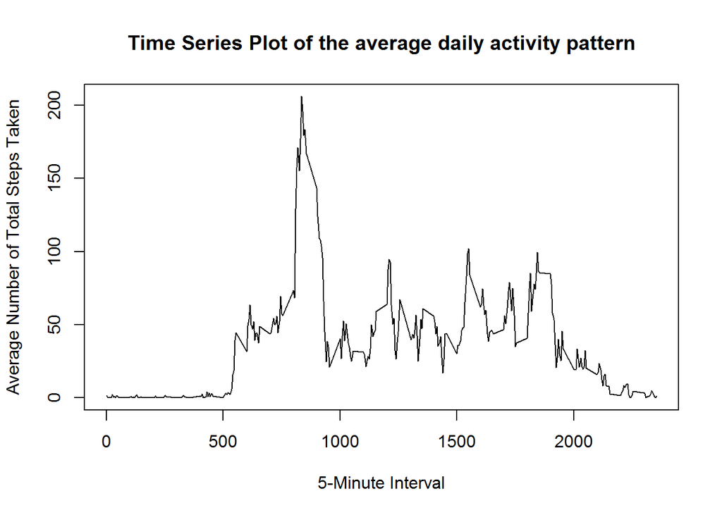

```r
plot(x = interval$interval, y = interval$steps, type = "l", main = "Time Series Plot of the average daily activity pattern", xlab = "5-Minute Interval", ylab = "Average Number of Total Steps Taken")
```

### Which 5-minute interval, on average across all the days in the dataset, contains the maximum number of steps?

```r
interval[interval$steps==max(interval$steps),]
```

```
##     interval    steps
## 104      835 206.1698
```

### Imputing missing values

Calculate and report the total number of missing values in the dataset (i.e. the total number of rows with NAs). I will use the sum() and is.na() to do this.

```r
sum(is.na(activitydata))
```

```
## [1] 2304
```

### Code to describe and show a strategy for imputing missing data

```r
new_data<- activitydata
new_data$steps[is.na(new_data$steps)] <- mean(data$steps, na.rm=TRUE)
```

### Histogram of the total number of steps taken each day after missing values are imputed

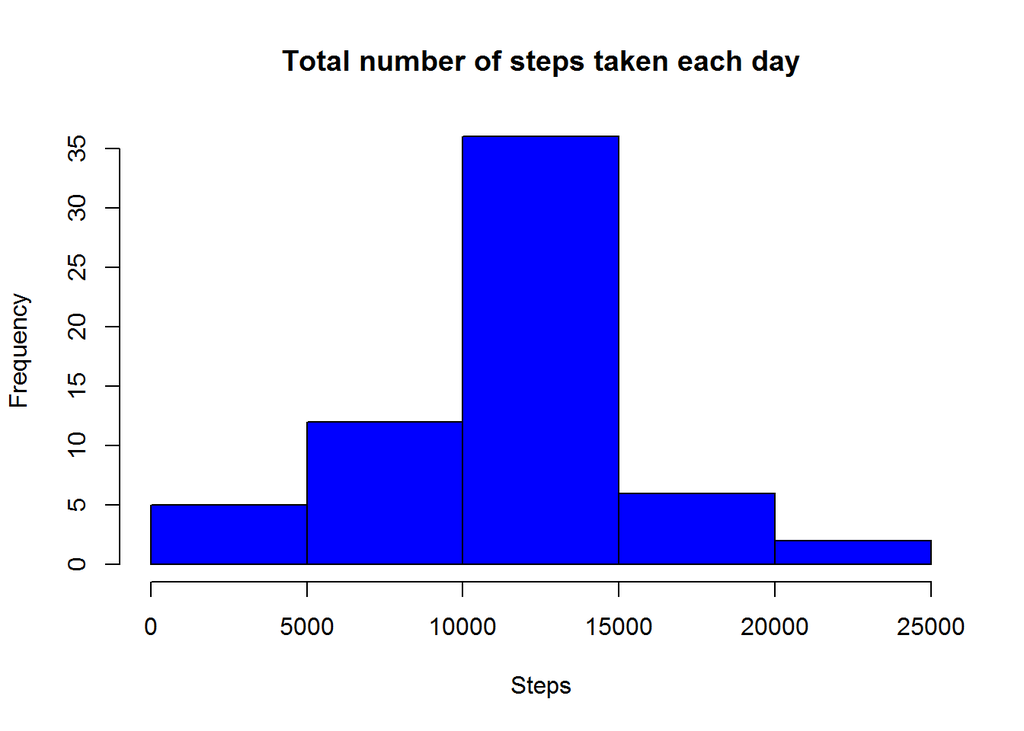

```r
totalsteps <- aggregate(steps ~ date, new_data, sum)
hist(totalsteps$steps, main="Total number of steps taken each day", col = "blue", xlab="Steps", ylab="Frequency")
```

### Calculate and report the mean and median total number of steps taken per day for the new dataset

```r
mean(totalsteps$steps)
```

```
## [1] 10766.19
```

```r
median(totalsteps$steps)
```

```
## [1] 10766.19
```

### What is the impact of imputing missing data on the estimates of the total daily number of steps?

When you use the mean or median to impute as missing values there is negligible change on the estimates.

### Are there differences in activity patterns between weekdays and weekends?

### Create a new factor variable in the dataset with two levels - “weekday” and “weekend” indicating whether a given date is a weekday or weekend day.

First load the dplyr library

```r
library(dplyr)
new_data <- new_data %>%
mutate(typeofday= ifelse(weekdays(new_data$date)=="Saturday" | weekdays(new_data$date)=="Sunday", "Weekend", "Weekday"))
head(new_data)
```

```
##     steps       date interval typeofday
## 1 37.3826 2012-10-01        0   Weekday
## 2 37.3826 2012-10-01        5   Weekday
## 3 37.3826 2012-10-01       10   Weekday
## 4 37.3826 2012-10-01       15   Weekday
## 5 37.3826 2012-10-01       20   Weekday
## 6 37.3826 2012-10-01       25   Weekday
```

### Make a panel plot containing a time series plot (i.e. type = “l”) of the 5-minute interval (x-axis) and the average number of steps taken, averaged across all weekday days or weekend days (y-axis).

Get the average number of steps taken, averaged across all days for each 5-minute

```r
newinterval <- aggregate(steps ~ interval + typeofday, new_data, mean)
```

### plot time series using the lattice package.

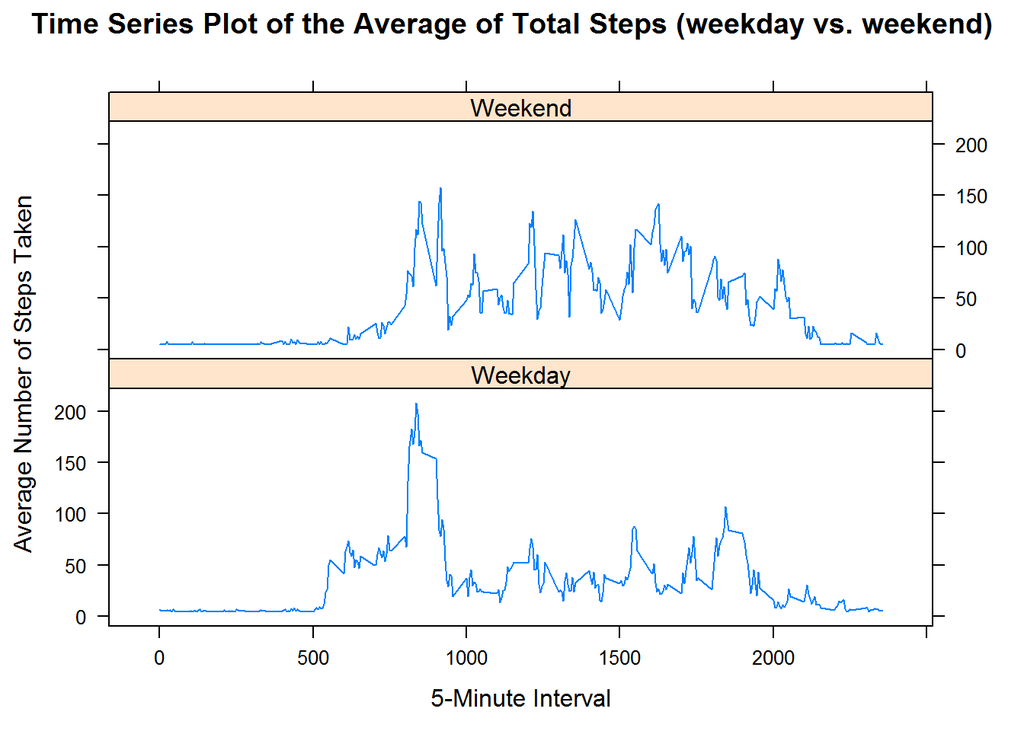

```r
library(lattice)
xyplot(steps ~ interval | typeofday, newinterval, type = "l", layout = c(1,2), main = "Time Series Plot of the Average of Total Steps (weekday vs. weekend)", xlab = "5-Minute Interval", ylab = "Average Number of Steps Taken")
```